# 560 Lecture 4 - Confidence intervals and user-defined functions

Douglas M. Fowler

3/26/2017

## First, a brief primer on user-defined functions in R.

Functions are part of a program/script that perform a specific action but are not, in themselves, a complete program/script. They take parameters/arguments, do something with them and then return the result. They can be thought of as a way of organizing/modularizing code. In R, they take the general form:

myfunction = function(arg1, arg2, …){ statments return(object) }

Note – generally you put statements inside the curly braces that define the body of the function. Each line of the function can be separated with either a carriage return or a semicolons. Semicolons are useful if you want to write a short function in R shell. Carriage returns look nicer in scripts. The last line of a function is often return(…) which passes whatever is inside back to the R shell/running script.

#### Here is a simple example:

```r
add2numbers = function(num1, num2){
sum = num1 + num2
return(sum)
}

add2numbers(1, 2)
```

```
## [1] 3
```

#### Functions can be nested, that is, functions can call other functions. Here is an example:

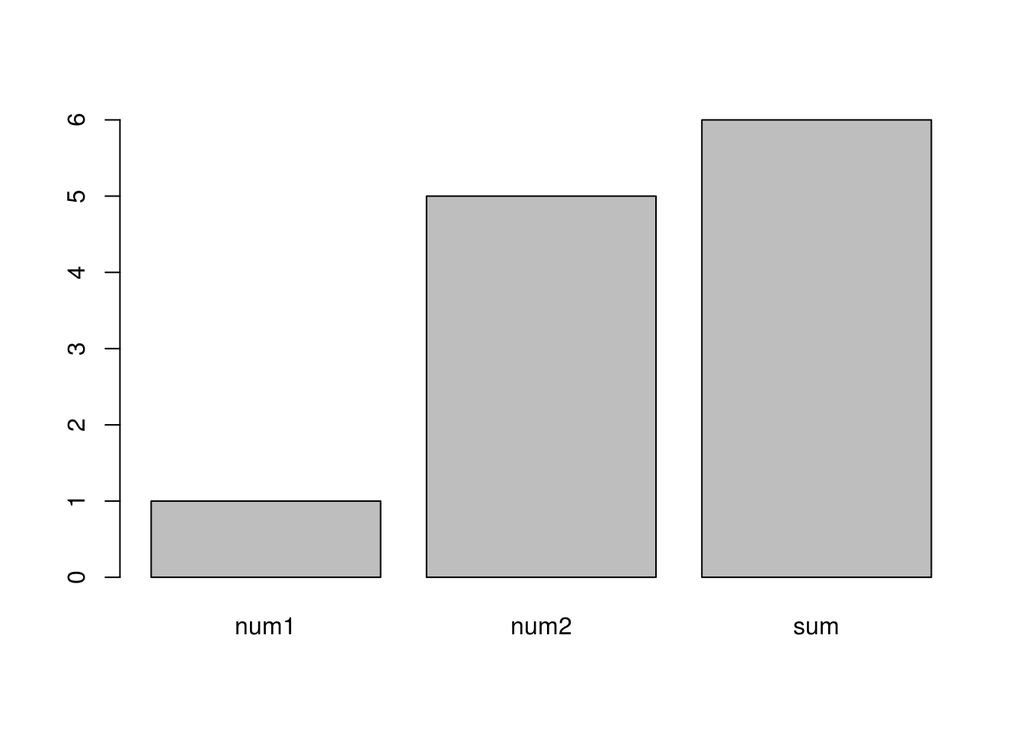

```r
plot.sum = function(num1, num2) {
values = c(num1, num2, add2numbers(num1, num2))
barplot(values, names.arg= c("num1", "num2", "sum"))
}

plot.sum(1, 5)
```

#### If you are writing a complex function in R, you can sanity check your arguments to make sure they are sensible. stopifnot() is a convenient way to do this. Let’s redefine add2numbers so that it checks to make sure the arguments are reals.

```r
add2numbers("a", 5)

add2numbers <- function(num1, num2){
stopifnot(is.double(num1), is.double(num2))
sum = num1 + num2
return(sum)
}

add2numbers(1, 5)
add2numbers("a", 5)
```

#### A few further general observations for coding (and Ring):

1. Comment your code
2. RTFM before you rely on whatever nifty package/code from your buddy/etc
3. Start from the beginning and break the task into meaningful steps. Then, write.
4. Use names that mean something. “foo” “ass” or “a” are not informative…
5. Test (using simulated data, etc) that your code actually works. Just getting a number doesn’t mean it’s working as intended.
6. In R, avoid iteration (I’ll show you why before we’re done)

#### Now, on to our confidence interval example.

Write a function in R that calculates confidence intervals for a normally-distributed sampling distribution. You should pass the desired CI (e.g. 95% or 0.95 or whatever), sample mean, standard deviation and size to the function. The function should use the t-distribution (dt(), pt(), rt()) to return the upper and lower bounds of the interval. The t-distribution depends on the sample size, too, a parameter that is called “degrees of freedom” and is equal to n-1. Challenge #1: see if you can have your function verify that the sample size parameter is an integer and stop, if not. Challenge #2: have your function print the results in a reasonably legible format and also return() them so you can capture the output in a script. Challenge #3: modify your function such that it will use a normal distribution if the sample size is greater than 30 and a t-distribution if the sample size is less than or equal to 30 (hint: you will need an if statement).

#### Next, use your function to put 95% confidence intervals on your reported_effects scores

```r
ww_data = read.table(file="http://faculty.washington.edu/dfowler/teaching/2016/GNOM560/560_ww_data.txt", header = T, sep = '\t')

conf_interval(0.95, mean(ww_data$reported_effect), sd(ww_data$reported_effect), length(ww_data$reported_effect))
```